# WP1: Simple View - Focusing on shape over level - Subsample B

## All model summaries

```r
# Combine all summary tables
all_summaries <- bind_rows( fmm3_summary, lpa4_summary)

# Extract number of classes modelled in class enumeration process
k_classes_modelled <- max(all_summaries$Classes, na.rm = TRUE)

# Specify table row for selected models for each spec
a_row <- fmm3_final_nclass
b_row <- (1*k_classes_modelled) + lpa4_final_nclass

# Format table, highlight class model of best fit in each specification
summary_table <- all_summaries %>%
  select(-bLRT_p, -VLMR_p, -BF, -cmP_k) %>%
  mutate(across(where(is.numeric), round, 2)) %>%
  mutate(LMR_p = ifelse(LMR_p == 0, "<0.01", LMR_p)) %>%
  replace(is.na(.), "-")

summary_table %>%
  mutate(Specification = " ") %>%
  kbl(align = c("l", "c", "r", "c", "r", "r", "r","r")) %>%
  kable_classic(html_font = "Cambria") %>%
  pack_rows(index = c("Shape FMM" = k_classes_modelled, "Shape LPA" = k_classes_modelled)) %>%
  row_spec(c(a_row, b_row, bold = T))  # edit for row numbers of selected models within each model spec
```

Specification

Classes

LL

Parameters

BIC

CAIC

AWE

LMR_p

**Shape FMM**

1

-56606.66

21

113384.22

113405.22

113415.72

2

-55572.40

31

111397.09

111428.09

111443.59

<0.01

3

-55340.58

41

111014.83

111055.83

111076.33

<0.01

4

-55099.23

51

110613.51

110664.51

110690.01

<0.01

5

-54875.34

61

110247.12

110308.11

110338.61

<0.01

6

-54810.25

71

110198.31

110269.31

110304.81

0.39

7

-54764.36

81

110187.91

110268.91

110309.41

0.23

8

-54719.23

91

110179.05

110270.05

110315.55

<0.01

**Shape LPA**

1

-47188.91

21

94548.73

94569.73

94580.23

2

-46154.49

32

92569.40

92601.40

92617.40

<0.01

3

-45348.61

43

91047.17

91090.17

91111.67

<0.01

4

-44879.47

54

90198.41

90252.41

90279.41

0.01

5

-44486.31

65

89501.60

89566.60

89599.10

0.03

6

-44161.68

76

88941.87

89017.87

89055.87

0.13

7

-43882.22

87

88472.47

88559.47

88602.97

0.18

8

-43681.29

98

88160.13

88258.13

88307.13

0.60

```r
# Save table as pdf for later viewing
write.csv(summary_table, "../output/tables/shapeB_model_indices.csv", row.names = FALSE)
```

Combine the fit indices into a single plot.

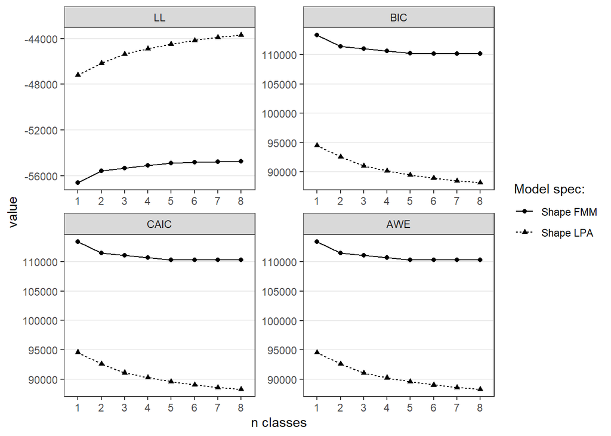

```r
# Grouped elbow plots
all_summaries %>%
    mutate(model_spec = Specification) %>%
    select(model_spec, Classes, LL, BIC, CAIC, AWE) %>%
    pivot_longer(LL:AWE, names_to = "statistic", values_to = "value") %>%
    mutate(statistic_relevel = factor(statistic, levels = c("LL", "BIC", "CAIC", "AWE"))) %>%
    ggplot(aes(x = as.factor(Classes), y = value)) +
    geom_point(aes(shape = model_spec)) +
    geom_line(aes(group = model_spec, linetype = model_spec)) +
    xlab("n classes") +
    theme_bw() +
    theme(panel.grid.major.x = element_blank(),
          panel.grid.minor.y = element_blank()) +
    facet_wrap(statistic_relevel ~., scales = "free") +
    labs(shape = "Model spec:", linetype = "Model spec:")
```

```r
# save out
ggsave("../output/figures/shapeB_all_indices.tiff", dpi = 600, width = 7, height = 4, units = "in")
```

## Final model

*As with the initial models on subset A, the LPA with general ability included as a covariate showed better fit to the data than the factor mixture alternative. The 6-class model successfully identified a poor comprehender group, and the profiles looked stable in comparison to initial model fitting. We are therefore reassured that the 6-class model is robust, and take this model forward to our next research question.*

```r
readModels("mplus_models/simpview/shapeB/sv_lpa4_rerun_6class.out", what="parameters")$parameters$r2 %>% kable("pipe")
```

| param | est | se | est_se | pval | LatentClass |
| --- | --- | --- | --- | --- | --- |
| NARACOMP | 0.712 | 0.017 | 42.032 | 0 | 1 |
| NARAACC | 0.998 | 0.000 | 5078.296 | 0 | 1 |
| COMBACC | 0.741 | 0.049 | 15.053 | 0 | 1 |
| WOLDCOMP | 0.077 | 0.010 | 7.498 | 0 | 1 |
| NARACOMP | 0.938 | 0.008 | 123.943 | 0 | 2 |
| NARAACC | 0.999 | 0.000 | ******** | 0 | 2 |
| COMBACC | 0.924 | 0.007 | 130.268 | 0 | 2 |
| WOLDCOMP | 0.132 | 0.015 | 8.652 | 0 | 2 |
| NARACOMP | 0.925 | 0.009 | 100.698 | 0 | 3 |
| NARAACC | 0.999 | 0.000 | ******** | 0 | 3 |
| COMBACC | 0.931 | 0.009 | 102.501 | 0 | 3 |
| WOLDCOMP | 0.157 | 0.020 | 7.653 | 0 | 3 |
| NARACOMP | 0.808 | 0.028 | 29.079 | 0 | 4 |
| NARAACC | 0.998 | 0.000 | 2759.657 | 0 | 4 |
| COMBACC | 0.744 | 0.022 | 33.681 | 0 | 4 |
| WOLDCOMP | 0.126 | 0.016 | 7.828 | 0 | 4 |
| NARACOMP | 0.784 | 0.030 | 26.122 | 0 | 5 |
| NARAACC | 0.995 | 0.001 | 978.193 | 0 | 5 |
| COMBACC | 0.755 | 0.026 | 28.698 | 0 | 5 |
| WOLDCOMP | 0.158 | 0.023 | 7.002 | 0 | 5 |
| NARACOMP | 0.945 | 0.019 | 50.441 | 0 | 6 |
| NARAACC | 1.000 | 0.000 | ******** | 0 | 6 |
| COMBACC | 0.946 | 0.018 | 52.036 | 0 | 6 |
| WOLDCOMP | 0.150 | 0.020 | 7.595 | 0 | 6 |

```r
readModels("mplus_models/simpview/shapeB/sv_lpa4_rerun_6class.out", what="parameters")$parameters$stdyx.standardized %>% kable("pipe")
```

| paramHeader | param | est | se | est_se | pval | LatentClass |
| --- | --- | --- | --- | --- | --- | --- |
| COMBACC.ON | F9AGE | 0.227 | 0.020 | 11.471 | 0.000 | 1 |
| COMBACC.ON | G | 0.831 | 0.026 | 31.995 | 0.000 | 1 |
| NARAACC.ON | F9AGE | 0.329 | 0.007 | 45.172 | 0.000 | 1 |
| NARAACC.ON | G | 0.943 | 0.003 | 370.879 | 0.000 | 1 |
| NARACOMP.ON | F9AGE | 0.279 | 0.018 | 15.740 | 0.000 | 1 |
| NARACOMP.ON | G | 0.796 | 0.011 | 75.129 | 0.000 | 1 |
| WOLDCOMP.ON | F8AGE | 0.036 | 0.019 | 1.927 | 0.054 | 1 |
| WOLDCOMP.ON | G | 0.275 | 0.018 | 15.051 | 0.000 | 1 |
| NARACOMP.WITH | NARAACC | 0.000 | 0.000 | 999.000 | 999.000 | 1 |
| NARACOMP.WITH | COMBACC | 0.000 | 0.000 | 999.000 | 999.000 | 1 |
| NARACOMP.WITH | WOLDCOMP | 0.000 | 0.000 | 999.000 | 999.000 | 1 |
| NARAACC.WITH | COMBACC | 0.000 | 0.000 | 999.000 | 999.000 | 1 |
| NARAACC.WITH | WOLDCOMP | 0.000 | 0.000 | 999.000 | 999.000 | 1 |
| COMBACC.WITH | WOLDCOMP | 0.000 | 0.000 | 999.000 | 999.000 | 1 |
| F9AGE.WITH | F8AGE | 0.058 | 0.025 | 2.302 | 0.021 | 1 |
| Means | F8AGE | 48.640 | 1.118 | 43.496 | 0.000 | 1 |
| Means | F9AGE | 30.646 | 0.613 | 49.956 | 0.000 | 1 |
| Intercepts | NARACOMP | -4.517 | 0.530 | -8.516 | 0.000 | 1 |
| Intercepts | NARAACC | -6.386 | 0.094 | -67.577 | 0.000 | 1 |
| Intercepts | COMBACC | -3.006 | 0.475 | -6.323 | 0.000 | 1 |
| Intercepts | WOLDCOMP | 2.204 | 0.901 | 2.447 | 0.014 | 1 |
| Variances | F8AGE | 1.000 | 0.000 | 999.000 | 999.000 | 1 |
| Variances | F9AGE | 1.000 | 0.000 | 999.000 | 999.000 | 1 |
| Residual.Variances | NARACOMP | 0.288 | 0.017 | 17.002 | 0.000 | 1 |
| Residual.Variances | NARAACC | 0.002 | 0.000 | 10.314 | 0.000 | 1 |
| Residual.Variances | COMBACC | 0.259 | 0.049 | 5.253 | 0.000 | 1 |
| Residual.Variances | WOLDCOMP | 0.923 | 0.010 | 89.711 | 0.000 | 1 |
| COMBACC.ON | F9AGE | 0.199 | 0.014 | 14.291 | 0.000 | 2 |
| COMBACC.ON | G | 0.940 | 0.004 | 238.949 | 0.000 | 2 |
| NARAACC.ON | F9AGE | 0.261 | 0.006 | 43.216 | 0.000 | 2 |

[output cut: 132 more lines]

This model is returned to the cross-validation procedure for final fitting (WP1_SimpView_ShapeValidation.Rmd).

# Version info

*Package versions were up-to-date as of 12/08/2021.* *LPA models were run using Mplus Version 8.5.*